# Measures of Central Tendency

Measures of central tendency se hum data ka center samajhte hain,  
- matlab wo value jo data ka typical ya representative value hoti hai.  
- Yeh measures batate hain ke data kahan clustered hai.

- Core Measures of Central Tendency:
  - Mean (Arithmetic Average)
  - Median
  - Mode
- 1 Mean
  - Mean ko hum average bhi kehte hain.
  - Yeh wo value hoti hai jo data set ke central point ko represent karti hai.
  - Iska calculation simple hai—sabhi numbers ko add karo aur unka total number of items se divide karo.

[figure not shown]

```python
import matplotlib.pyplot as plt
import pandas as pd
```

```python
data = [4, 7, 2, 9, 5, 8, 6]
data
```

```
[4, 7, 2, 9, 5, 8, 6]
```

```python
count = 0
for i in data:
    count += i
count
```

```
41
```

```python
len(data)
```

```
7
```

```python
mean = count / len(data)
mean
```

```
5.857142857142857
```

Visualize Mean

```python
df = pd.DataFrame({"Values": data})
df
```

|  | Values |
| --- | --- |
| 0 | 4 |
| 1 | 7 |
| 2 | 2 |
| 3 | 9 |
| 4 | 5 |
| 5 | 8 |
| 6 | 6 |

```python
# pandas mean() function
mean_val = df["Values"].mean()
mean_val
```

```
np.float64(5.857142857142857)
```

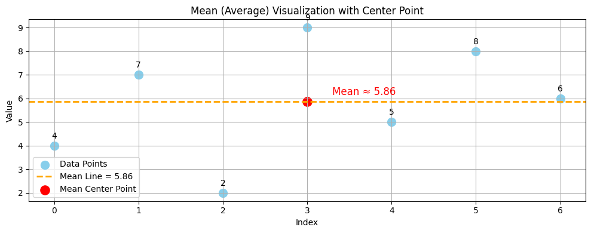

```python
# Plot setup
plt.figure(figsize=(10, 4))
x = range(len(df))
plt.scatter(x, df["Values"], color="skyblue", label="Data Points", s=100)

plt.axhline(
    mean_val,
    color="orange",
    linestyle="--",
    linewidth=2,
    label=f"Mean Line = {mean_val:.2f}",
)

plt.scatter(
    len(data) // 2, mean_val, color="red", s=120, marker="o", label="Mean Center Point"
)

for i, val in enumerate(data):
    plt.text(i, val + 0.3, str(val), ha="center", fontsize=10)

plt.text(
    len(data) // 2 + 0.3,
    mean_val + 0.3,
    f"Mean ≈ {mean_val:.2f}",
    color="red",
    fontsize=12,
)

# Labels and grid
plt.title("Mean (Average) Visualization with Center Point")
plt.xlabel("Index")
plt.ylabel("Value")
plt.grid(True)
plt.legend()
plt.tight_layout()
plt.show()
```

- Har dot ek value ko represent karta hai.
- Orange line mean value ko show karti hai — yani center jahan data around ghoom raha hai.
- 2 Median
  - Median wo value hoti hai jo data ko half mein divide karti hai.
  - Agar data sorted hai toh:
    - Odd number of data points: Median = Middle element
    - Even number of data points: Median = Average of two middle elements

[figure not shown]

```python
data
```

```
[4, 7, 2, 9, 5, 8, 6]
```

```python
sorted(data)
```

```
[2, 4, 5, 6, 7, 8, 9]
```

```python
len(data) // 2
```

```
3
```

```python
median = sorted(data)[(len(data) // 2)]
median
```

```
6
```

Visualize Median

```python
data = [4, 7, 2, 9, 5, 8, 6]
df = pd.DataFrame({"Values": data})
df
```

|  | Values |
| --- | --- |
| 0 | 4 |
| 1 | 7 |
| 2 | 2 |
| 3 | 9 |
| 4 | 5 |
| 5 | 8 |
| 6 | 6 |

```python
median_val = df["Values"].median()
median_val
```

```
np.float64(6.0)
```

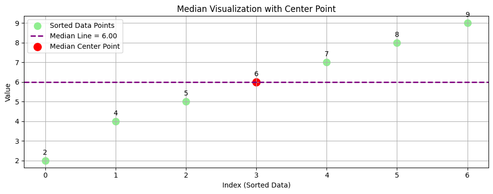

```python
sorted_data = sorted(data)

# Plot
plt.figure(figsize=(10, 4))
x = range(len(sorted_data))

plt.scatter(x, sorted_data, color="lightgreen", s=100, label="Sorted Data Points")
plt.axhline(
    median_val,
    color="purple",
    linestyle="--",
    linewidth=2,
    label=f"Median Line = {median_val:.2f}",
)

plt.scatter(
    len(sorted_data) // 2, median_val, color="red", s=120, label="Median Center Point"
)
# Annotate each value
for i, val in enumerate(sorted_data):
    plt.text(i, val + 0.3, str(val), ha="center", fontsize=10)

plt.title("Median Visualization with Center Point")
plt.xlabel("Index (Sorted Data)")
plt.ylabel("Value")
plt.legend()
plt.grid(True)
plt.tight_layout()
plt.show()
```

- Data ko sort kiya gaya [2, 4, 5, 6, 7, 8, 9]
- Median line purple color se center pe draw hui (6)
- Red dot show kar raha hai ke center value kya hai
- Baaki green dots data values hain

Differences in -> Mean | Median

```python
data = [4, 7, 2, 9, 5, 8, 6]
df = pd.DataFrame({"Values": data})
```

```python
mean_val = df["Values"].mean()
median_val = df["Values"].median()

print("mean", mean_val)
print("median", median_val)
```

```
mean 5.857142857142857
median 6.0
```

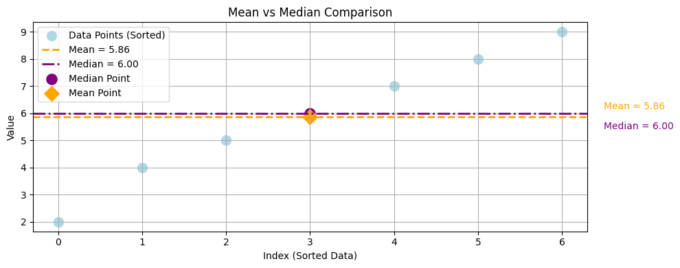

```python
sorted_data = sorted(data)

plt.figure(figsize=(10, 4))
x = range(len(sorted_data))

plt.scatter(x, sorted_data, color="lightblue", s=100, label="Data Points (Sorted)")
plt.axhline(
    mean_val,
    color="orange",
    linestyle="--",
    linewidth=2,
    label=f"Mean = {mean_val:.2f}",
)
plt.axhline(
    median_val,
    color="purple",
    linestyle="-.",
    linewidth=2,
    label=f"Median = {median_val:.2f}",
)

# Highlight Points
plt.scatter(
    len(sorted_data) // 2,
    median_val,
    color="purple",
    s=120,
    marker="o",
    label="Median Point",
)
plt.scatter(
    len(sorted_data) // 2,
    mean_val,
    color="orange",
    s=120,
    marker="D",
    label="Mean Point",
)

plt.text(
    len(sorted_data) - 0.5,
    mean_val + 0.3,
    f"Mean ≈ {mean_val:.2f}",
    color="orange",
    fontsize=10,
)
plt.text(
    len(sorted_data) - 0.5,
    median_val - 0.6,
    f"Median = {median_val:.2f}",
    color="purple",
    fontsize=10,
)

plt.title("Mean vs Median Comparison")
plt.xlabel("Index (Sorted Data)")
plt.ylabel("Value")
plt.legend()
plt.grid(True)
plt.tight_layout()
plt.show()
```

```python
data = [4, 7, 2, 9, 5, 8, 6, 100]
```

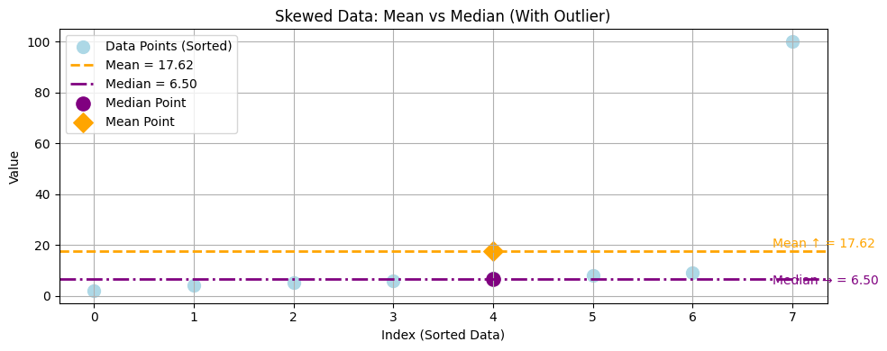

```python
df = pd.DataFrame({"Values": data})
mean_val = df["Values"].mean()
median_val = df["Values"].median()
sorted_data = sorted(data)

plt.figure(figsize=(10, 4))
x = range(len(sorted_data))

plt.scatter(x, sorted_data, color="lightblue", s=100, label="Data Points (Sorted)")
plt.axhline(
    mean_val,
    color="orange",
    linestyle="--",
    linewidth=2,
    label=f"Mean = {mean_val:.2f}",
)
plt.axhline(
    median_val,
    color="purple",
    linestyle="-.",
    linewidth=2,
    label=f"Median = {median_val:.2f}",
)
plt.scatter(
    len(sorted_data) // 2,
    median_val,
    color="purple",
    s=120,
    marker="o",
    label="Median Point",
)
plt.scatter(
    len(sorted_data) // 2,
    mean_val,
    color="orange",
    s=120,
    marker="D",
    label="Mean Point",
)
plt.text(
    len(sorted_data) - 1.2,
    mean_val + 1.5,
    f"Mean ↑ = {mean_val:.2f}",
    color="orange",
    fontsize=10,
)
plt.text(
    len(sorted_data) - 1.2,
    median_val - 2,
    f"Median → = {median_val:.2f}",
    color="purple",
    fontsize=10,
)

plt.title("Skewed Data: Mean vs Median (With Outlier)")
plt.xlabel("Index (Sorted Data)")
plt.ylabel("Value")
plt.legend()
plt.grid(True)
plt.tight_layout()
plt.show()
```

| Feature 🔍 | **Mean (Average)** | **Median (Middle Value)** |
| --- | --- | --- |
| 📌 **Purpose** | Sab values ka average nikalna | Mid wali value dikhana |
| 🧮 **Calculation** | Sum of all values ÷ number of values | Sorted list ka center value |
| 📊 **Use kab hota hai?** | Jab data symmetrical aur clean ho | Jab data skewed ya uneven ho |
| 📦 **Sorted Data chahiye?** | ❌ Nahi zarurat | ✅ Haan zaroori hai |
| 💡 **Kya represent karta hai?** | Central trend with balance | True middle of data |

- 3 Mode
  - Mode wo value hoti hai jo sabse zyada baar repeat hoti hai data mein.

[figure not shown]

```python
data = [4, 7, 2, 9, 5, 8, 6, 4, 4, 7]
data
```

```
[4, 7, 2, 9, 5, 8, 6, 4, 4, 7]
```

```python
tmp = []
for i in data:
    if i not in tmp:
        print(i, "->", data.count(i))
    tmp.append(i)
```

```
4 -> 3
7 -> 2
2 -> 1
9 -> 1
5 -> 1
8 -> 1
6 -> 1
```

```python
tmp = []
counts = {}

for i in data:
    if i not in tmp:
        counts[i] = data.count(i)
    tmp.append(i)

counts
```

```
{4: 3, 7: 2, 2: 1, 9: 1, 5: 1, 8: 1, 6: 1}
```

```python
max(counts.items(), key=lambda key: key[1])
```

```
(4, 3)
```

```python
mode = max(counts.items(), key=lambda key: key[1])[0]
mode
```

```
4
```

```python
df = pd.DataFrame({"Values": data})
df
```

|  | Values |
| --- | --- |
| 0 | 4 |
| 1 | 7 |
| 2 | 2 |
| 3 | 9 |
| 4 | 5 |
| 5 | 8 |
| 6 | 6 |
| 7 | 4 |
| 8 | 4 |
| 9 | 7 |

```python
counts
```

```
{4: 3, 7: 2, 2: 1, 9: 1, 5: 1, 8: 1, 6: 1}
```

```python
mode_val = df["Values"].mode()[0]
mode_val
```

```
np.int64(4)
```

Visualize Mode

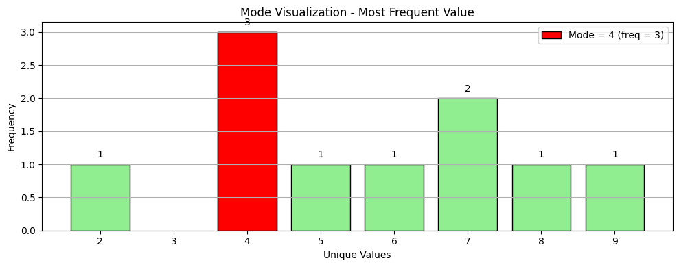

```python
plt.figure(figsize=(10, 4))
plt.bar(counts.keys(), counts.values(), color="lightgreen", edgecolor="black")

plt.bar(
    mode_val,
    counts[mode_val],
    color="red",
    edgecolor="black",
    label=f"Mode = {mode_val} (freq = {counts[mode_val]})",
)

for val, freq in counts.items():
    plt.text(val, freq + 0.1, f"{freq}", ha="center", fontsize=10)

# Titles
plt.title("Mode Visualization - Most Frequent Value")
plt.xlabel("Unique Values")
plt.ylabel("Frequency")
plt.legend()
plt.grid(True, axis="y")
plt.tight_layout()
plt.show()
```

| Feature | Mean | Median | Mode |
| --- | --- | --- | --- |
| Kya batata hai? | Average value | Middle value | Most frequent value |
| Outlier sensitive? | ✅ Yes | ❌ No | ❌ No |
| Categorical pe kaam? | ❌ Nahi | ❌ Limited | ✅ Perfect |
| Numerical data? | ✅ Yes | ✅ Yes | ✅ Yes |

| Condition / Situation | ✅ Use Mean | ✅ Use Median | ✅ Use Mode | 🔎 Explanation |
| --- | --- | --- | --- | --- |
| 📈 **Balanced numerical data** | ✅ Yes | ✅ Yes | ❌ Rarely | Mean aur Median dono accurate center dikhate hain |
| ⚠️ **Data mein outliers hon** | ❌ No | ✅ Yes | ❌ Maybe | Median zyada reliable hoti hai |
| 🔀 **Skewed (uneven) data** | ❌ No | ✅ Yes | ❌ No | Median real center show karta hai |
| 📉 **Normal (bell-shaped) distribution** | ✅ Yes | ✅ Yes | ✅ Maybe | Sab close hotay hain — koi bhi kaam kar sakta hai |
| 🔡 **Categorical data (e.g. Shirt, Pant)** | ❌ No | ❌ No | ✅ Yes | Mode hi kaam karta hai — most frequent value |
| 🧩 **Ordinal data (e.g. Poor, Good, Excellent)** | ❌ No | ✅ Yes | ✅ Yes | Median + Mode dono useful — average rank ya most frequent |
| 🧼 **Missing value fill — numerical balanced** | ✅ Yes | ✅ Yes | ❌ No | Mean ya Median use hoti hain |
| 🧼 **Missing value fill — skewed/outlier data** | ❌ No | ✅ Yes | ❌ No | Median safe hoti hai from distortion |
| 🧼 **Missing value fill — categorical** | ❌ No | ❌ No | ✅ Yes | Mode sabse zyada common value fill karta hai |
| 🧮 **Data center chahiye (center of tendency)** | ✅ Yes | ✅ Yes | ❌ No | Center ke liye mean/median better hotay hain |
| 📊 **Data summary (quick idea)** | ✅ Yes | ✅ Yes | ✅ Yes | Teeno ka use ek sath bhi hota hai |
| 🤖 **ML: Standardization (x - mean / std)** | ✅ Required | ❌ No | ❌ No | Mean required hota hai Standard Scaler ke liye |
| 🤖 **ML: Robust Scaler / Skewed Data** | ❌ No | ✅ Yes | ❌ No | Median based scaling zyada stable hoti hai |
| 🧠 **User behavior ya product trend analysis** | ❌ No | ❌ No | ✅ Yes | Mode se most common item find hota hai |

# Some More Measures of Central Tendency

- 3 Geometric Mean
  - Geometric Mean aik multiplicative average hota hai.
  - Jab values multiply hoti hain (jaise: growth rate, population, investment), tab use hota hai..

[figure not shown]

```python
data = [4, 9]
data
```

```
[4, 9]
```

```python
mul = 1
for i in data:
    mul = mul * i
mul
```

```
36
```

```python
n = len(data)
n
```

```
2
```

```python
# underroot of 1/n
mul ** (1 / n)
```

```
6.0
```

Differences in -> Mean | Geometric Means

```python
simple_mean = sum(data) / len(data)
simple_mean
```

```
6.5
```

```python
mul = 1
for i in data:
    mul = mul * i

gm = mul ** (1 / n)
gm
```

```
6.0
```

Visualize Geometric Mean

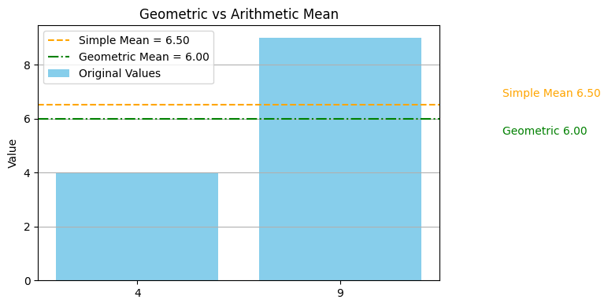

```python
plt.figure(figsize=(8, 4))
x = range(len(data))

# Data points
plt.bar(x, data, color="skyblue", label="Original Values")

plt.axhline(
    simple_mean,
    color="orange",
    linestyle="--",
    label=f"Simple Mean = {simple_mean:.2f}",
)
plt.axhline(gm, color="green", linestyle="-.", label=f"Geometric Mean = {gm:.2f}")

# Labels
plt.text(1.8, simple_mean + 0.3, f"Simple Mean {simple_mean:.2f}", color="orange")
plt.text(1.8, gm - 0.6, f"Geometric {gm:.2f}", color="green")

plt.xticks([0, 1], ["4", "9"])
plt.title("Geometric vs Arithmetic Mean")
plt.ylabel("Value")
plt.legend()
plt.grid(True, axis="y")
plt.tight_layout()
plt.show()
```

| Feature 🔍 | 🟠 **Simple (Arithmetic) Mean** | 🟢 **Geometric Mean** |
| --- | --- | --- |
| 📐 **Formula** | (x₁ + x₂ + x₃ + ... + xₙ) / n | (x₁ × x₂ × x₃ × ... × xₙ)^(1/n) |
| ➕ **Data kis type ka hota hai?** | Jab values **add ho rahi ho** (e.g. marks) | Jab values **multiply ho rahi ho** (e.g. growth rate) |
| 🔁 **Calculation logic** | Sab values ko add karo aur divide karo | Sab values ko multiply karo aur root lo |
| 📈 **Outlier ka effect** | Bohat zyada hota hai | Kam hota hai |
| ➗ **Zero allow karta hai?** | ✅ Haan | ❌ Nahi (0 multiply hone se result 0 ban jata hai) |
| ➖ **Negative values?** | ✅ Haan | ❌ Nahi (odd roots of negative = complex number) |
| 🧠 **Use kab hota hai?** | Jab values ki simple average chahiye | Jab values ratios ya % growth represent kar rahi ho |
| 🎯 **Real-world example** | Marks, height, age, exam score, salary | Investment growth, interest rate, population growth |
| 🧮 **Result interpretation** | Central value of data | Realistic average of %age or ratios |
| 📊 **Graph mein look** | Center of gravity | Slightly pulled toward smaller values |
| 🎯 **Use karo jab...** | ➕ Addition-based situations (score, marks) | ✖️ Multiplication-based (growth, interest, CPI) |

| Situation | Use This Mean | Reason |
| --- | --- | --- |
| Student ke marks ka average | ✅ Arithmetic Mean | Marks add hote hain |
| Paisa 3 saal tak grow ho +10%, +30% | ✅ Geometric Mean | Compound growth multiply hota hai |
| Height ka average | ✅ Arithmetic Mean | Normal addition-based metric |
| Price Index (CPI, inflation) | ✅ Geometric Mean | Prices multiply hoti hain (inflation effect) |
| Machine learning ke ratios / growth | ✅ Geometric Mean | Ratios aur scale zyada accurate hota hai |
| Mixed + Negative values present | ✅ Arithmetic Mean | Geometric mean invalid hoti hai negative/0 pe |

- 4 Harmonic Mean
  - Harmonic Mean tab use hoti hn jab values ratio form mein hoon (e.g. speed, km/hr, Rs/unit).
  - Ye lowest average hota hai — aur most accurate jab distance/time involve ho.

[figure not shown]

```python
data = [60, 40]
```

```python
flag = 0

for i in data:
    flag += 1 / i
flag
```

```
0.04166666666666667
```

```python
n = len(data)
n
```

```
2
```

```python
hm = n / flag
hm
```

```
47.99999999999999
```

Differences in -> Arithmetric Mean | Geometric Means | Harmonic Mean

```python
import numpy as np
from scipy.stats import gmean, hmean
```

```python
arith_mean = np.mean(data)
geo_mean = gmean(data)
harm_mean = hmean(data)
```

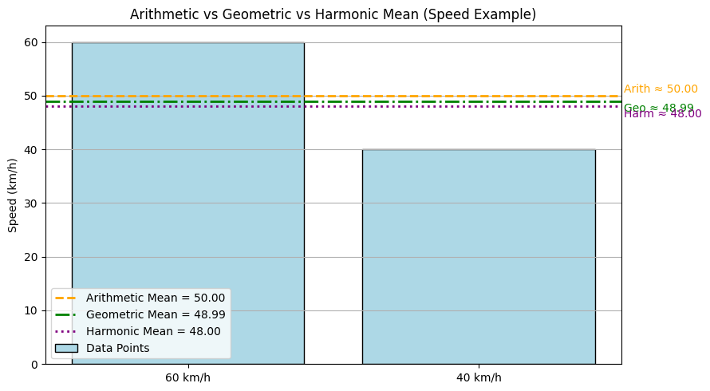

```python
plt.figure(figsize=(9, 5))
x = range(len(data))

plt.bar(x, data, color="lightblue", label="Data Points", edgecolor="black")

plt.axhline(
    arith_mean,
    color="orange",
    linestyle="--",
    linewidth=2,
    label=f"Arithmetic Mean = {arith_mean:.2f}",
)
plt.axhline(
    geo_mean,
    color="green",
    linestyle="-.",
    linewidth=2,
    label=f"Geometric Mean = {geo_mean:.2f}",
)
plt.axhline(
    harm_mean,
    color="purple",
    linestyle=":",
    linewidth=2,
    label=f"Harmonic Mean = {harm_mean:.2f}",
)

plt.text(1.5, arith_mean + 0.5, f"Arith ≈ {arith_mean:.2f}", color="orange")
plt.text(1.5, geo_mean - 2, f"Geo ≈ {geo_mean:.2f}", color="green")
plt.text(1.5, harm_mean - 2, f"Harm ≈ {harm_mean:.2f}", color="purple")

plt.xticks([0, 1], ["60 km/h", "40 km/h"])
plt.title("Arithmetic vs Geometric vs Harmonic Mean (Speed Example)")
plt.ylabel("Speed (km/h)")
plt.grid(True, axis="y")
plt.legend()
plt.tight_layout()
plt.show()
```

| 🔢 Mean Type | 🧠 **Core Difference** | 🧮 **Simple Equation** | 🎯 **Kab Use Karein? (Use-case)** |
| --- | --- | --- | --- |
| 🟠 **Arithmetic Mean** | Sab values ka **additive average** | (x1 + x2 + x3 + ... + xn) ÷ n | Jab values **add ho rahi ho** (marks, salary, height) |
| 🟢 **Geometric Mean** | Values ka **multiplicative average** | nth root of (x1 × x2 × x3 × ... × xn) | Jab values **percent ya ratio** form mein ho (growth, ROI) |
| 🟣 **Harmonic Mean** | Values ka **inverse average (per-unit based)** | n ÷ (1/x1 + 1/x2 + ... + 1/xn) | Jab values **speed ya rate** ho (distance/speed, Rs/unit) |

| Type | Use When... |
| --- | --- |
| Arithmetic Mean | Jab **normal average** chahiye (additive context) |
| Geometric Mean | Jab **growth, percentage ya compound effect** ho |
| Harmonic Mean | Jab **rate, speed, ya unit-per-time** cheezen ho |

- 5 Trimmed Mean
  - Trimmed Mean main kuch lowest aur highest values remove ki jati hn
  - Baki values ka normal average (mean) nikal detay ho.
  - Ye outliers (extreme values) ka effect kam kar deta hai, aur zyada reliable average deta hai.

  ```
   Step 1: Data ko sort karo
   Step 2: n = total number of items
   Step 3: x = trimming percentage (0.1 for 10%)
   Step 4: Remove x*n lowest values aur x*n highest values
   Step 5: Bachi hui values ka average lo
  ```

[figure not shown]

```python
# apply in function
def tm(data, percent):
    data = sorted(data)
    n = len(data)
    t = int(n * percent)
    return sum(data[t : n - t]) / (n - (2 * t))
```

```python
data = [10, 12, 13, 15, 17, 300]
data
```

```
[10, 12, 13, 15, 17, 300]
```

```python
tm(data, 1 / 6)
```

```
14.25
```

```python
# direct use tm in with scipy
from scipy.stats import trim_mean
```

```python
print(trim_mean(data, proportiontocut=1 / 6))
```

```
14.25
```

Visualize Trimmed Mean And Differences in Normal Means | Trimmed Mean

```python
import matplotlib.pyplot as plt
import numpy as np
import pandas as pd
import seaborn as sns
from scipy.stats import trim_mean
```

```python
# Data
data = [10, 12, 13, 15, 17, 300]
df = pd.DataFrame({"Values": data})
```

```python
# Normal Mean
normal_mean = np.mean(data)
normal_mean
```

```
np.float64(61.166666666666664)
```

```python
# Trimmed Mean (1 value from each side = 1/6 = 16.67%)
trimmed = trim_mean(data, proportiontocut=1 / 6)
trimmed
```

```
np.float64(14.25)
```

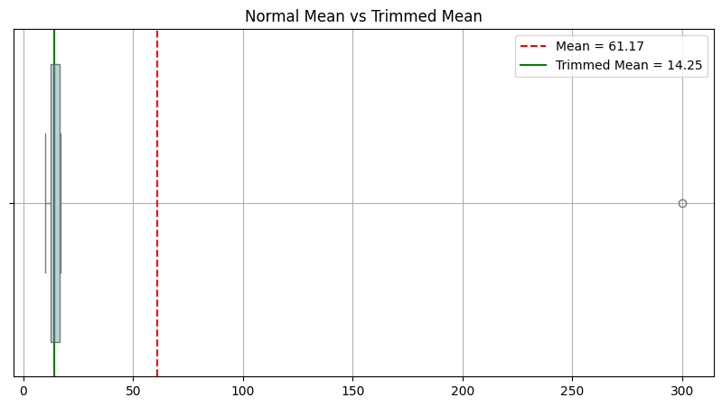

```python
# Visual
plt.figure(figsize=(10, 5))
sns.boxplot(data=data, orient="h", color="lightblue")
plt.axvline(normal_mean, color="red", linestyle="--", label=f"Mean = {normal_mean:.2f}")
plt.axvline(
    trimmed, color="green", linestyle="-", label=f"Trimmed Mean = {trimmed:.2f}"
)
plt.title("Normal Mean vs Trimmed Mean")
plt.legend()
plt.grid(True)
plt.show()
```

| Feature | Normal Mean | Trimmed Mean |
| --- | --- | --- |
| Sensitive to Outliers | ✅ Yes (300 ne 61.17 kar diya) | ❌ No (14.25 accurate center) |
| Best for | Clean, Normal Data | Noisy, Skewed Data |
| Use Case | Simple stats, reports | Medical, finance, ML input |

| Situation | Use This Mean |
| --- | --- |
| Sensor data with noise | ✅ Trimmed Mean |
| Income or salary analysis | ✅ Trimmed Mean |
| Clean scientific experiments | ✅ Normal Mean |
| Initial quick reports | ✅ Normal Mean |

- 6 Weighted Mean
  - Weighted Mean aik aisi average hai jahan har value ki apni importance (weight) hoti hai.
  - Har value ko uske weight se multiply kiya jata hai, phir total weight se divide kiya jata hai.
  - Jab har value ka barabar importance na ho — weighted mean use hota hai.

[figure not shown]

```python
values = [60, 70, 80]
weights = [1, 2, 3]
```

```python
sm = 0
for v, w in zip(values, weights):
    sm += v * w
wm = sm / sum(weights)
wm
```

```
73.33333333333333
```

Visualize Weighted Mean And Differences in Normal Means | Weighted Mean

```python
df = pd.DataFrame({"Values": values, "Weights": weights})

df
```

|  | Values | Weights |
| --- | --- | --- |
| 0 | 60 | 1 |
| 1 | 70 | 2 |
| 2 | 80 | 3 |

[figure not shown]

```python
# Weighted Mean Calculation
weighted_mean = sum(df["Values"] * df["Weights"]) / sum(df["Weights"])
normal_mean = df["Values"].mean()

# Plot

plt.figure(figsize=(8, 5))
sns.barplot(
    x="Values",
    y="Weights",
    data=df,
    hue="Values",
    palette="Blues",
    legend=False,
    edgecolor="black",
)
plt.axvline(
    normal_mean, color="red", linestyle="--", label=f"Normal Mean = {normal_mean:.2f}"
)
plt.axvline(
    weighted_mean,
    color="green",
    linestyle="-",
    label=f"Weighted Mean = {weighted_mean:.2f}",
)
plt.title("Weighted vs Normal Mean")
plt.legend()
plt.grid()
plt.show()
```

| Feature | Normal Mean | Weighted Mean |
| --- | --- | --- |
| Sab values barabar? | ✅ Yes | ❌ No (weight matters) |
| Kis cheez pe based? | Sirf values | Value × importance |
| Use kab karein? | Equal items | Jab kuch items more important hon |

| Use Case | Use Weighted Mean? |
| --- | --- |
| GPA calculation | ✅ Yes |
| Voting power per state | ✅ Yes |
| Survey where responses have different weight | ✅ Yes |
| Simple average of marks | ❌ No (use normal mean) |

- Jab higher values ka zyada weight ho, to weighted mean hamesha normal se upar ya neeche chala jata hai — depending on weights.
- 7 Moving Average
  - Moving Average (ya Rolling Average) aik technique hai jo:
    - Time-series ya sequential data ka smooth trend dekhne ke liye use hoti hai.
    - Ye ek sliding window hoti hai jo current + past values ka average leti hai.

[figure not shown]

```python
data = [10, 20, 30, 40, 50, 60]
k = 3
```

```python
def moving_average(data,k):
    points = []
    for i in range(len(data)):
        start = i - k + 1
        if start >= 0 :
            points.append(sum(data[start:i+1]) / 3)
    return points
```

```python
moving_average(data,k)
```

```
[20.0, 30.0, 40.0, 50.0]
```

Visualize Moving Average

```python
# Data: Time & Temperature
data = {
    "Time": ["0s", "1s", "2s", "3s", "4s", "5s"],
    "Temp": [22, 23, 24, 80, 25, 26]  # 80°C = sensor glitch
}

df = pd.DataFrame(data)
df
```

|  | Time | Temp |
| --- | --- | --- |
| 0 | 0s | 22 |
| 1 | 1s | 23 |
| 2 | 2s | 24 |
| 3 | 3s | 80 |
| 4 | 4s | 25 |
| 5 | 5s | 26 |

```python
df["Moving_Avg"] = df["Temp"].rolling(window=3).mean() # .rolling pandas built in method
df
```

|  | Time | Temp | Moving_Avg |
| --- | --- | --- | --- |
| 0 | 0s | 22 | NaN |
| 1 | 1s | 23 | NaN |
| 2 | 2s | 24 | 23.000000 |
| 3 | 3s | 80 | 42.333333 |
| 4 | 4s | 25 | 43.000000 |
| 5 | 5s | 26 | 43.666667 |

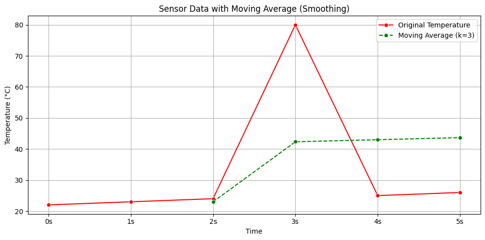

```python
plt.figure(figsize=(10, 5))
sns.lineplot(data=df, x="Time", y="Temp", label="Original Temperature", marker="o", color='red')
sns.lineplot(data=df, x="Time", y="Moving_Avg", label="Moving Average (k=3)", marker="o", linestyle="--", color='green')

plt.title("Sensor Data with Moving Average (Smoothing)")
plt.xlabel("Time")
plt.ylabel("Temperature (°C)")
plt.grid(True)
plt.legend()
plt.tight_layout()
plt.show()
```

| Time | Temp | Moving Avg |
| --- | --- | --- |
| 0s | 22 | NaN |
| 1s | 23 | NaN |
| 2s | 24 | 23.0 |
| 3s | 80 | 42.3 ❗ |
| 4s | 25 | 43.0 |
| 5s | 26 | 43.6 |

| Use | Benefit |
| --- | --- |
| ✅ Noise Removal | Sudden spikes ko average karta hai |
| ✅ Trend Detection | Data ka smooth direction dikhata hai |
| ✅ Feature Engineering | ML model ke liye stable features banata hai |
| ✅ Better Visualization | Graph samajhne mein asani |
| ✅ Anomaly Detection | Jab koi point bahut upar niche ho, to deviation detect hota hai |

- 8 Exponential Moving Average
  - Exponential Moving Average (EMA) aik aisi average technique hai
  - jo recent values ko zyada importance deti hai aur
  - purani values ko gradually kam consider karti hai.
- Exponential Moving Average sirf pichle kuch values ka average nahi hota,
- balke har naye data point ka effect zyada hota hai.
- Isse model ya graph recent changes ko jaldi samajh leta hai.

[figure not shown]

```python
data = [22, 23, 24, 80, 25, 26]
span = 3
```

```python
alpha = 2 / (span+1)
alpha
```

```
0.5
```

```python
prev_ema = 0
ema = []
for i in range(len(data)):
    if i == 0:
        ema.append(data[i])
        prev_ema = data[i]
    else:
        current_ema = alpha * data[i] + (1-alpha) * prev_ema
        ema.append(current_ema)
        prev_ema = current_ema
```

```python
ema
```

```
[22, 22.5, 23.25, 51.625, 38.3125, 32.15625]
```

Visualize Exponential Moving Average

```python
# Fake stock price data (daily)
days = pd.date_range(start="2024-01-01", periods=15)
prices = [100, 102, 105, 101, 98, 97, 99, 103, 110, 112, 111, 109, 107, 108, 106]
```

```python
# Create DataFrame
df = pd.DataFrame({
    "Date": days,
    "Price": prices
})
df
```

|  | Date | Price |
| --- | --- | --- |
| 0 | 2024-01-01 | 100 |
| 1 | 2024-01-02 | 102 |
| 2 | 2024-01-03 | 105 |
| 3 | 2024-01-04 | 101 |
| 4 | 2024-01-05 | 98 |
| 5 | 2024-01-06 | 97 |
| 6 | 2024-01-07 | 99 |
| 7 | 2024-01-08 | 103 |
| 8 | 2024-01-09 | 110 |
| 9 | 2024-01-10 | 112 |
| 10 | 2024-01-11 | 111 |
| 11 | 2024-01-12 | 109 |
| 12 | 2024-01-13 | 107 |
| 13 | 2024-01-14 | 108 |
| 14 | 2024-01-15 | 106 |

```python
# Calculate EMA (Exponential Moving Average)
df["EMA_5"] = df["Price"].ewm(span=5, adjust=False).mean() #.ewm pandas method
df
```

|  | Date | Price | EMA_5 |
| --- | --- | --- | --- |
| 0 | 2024-01-01 | 100 | 100.000000 |
| 1 | 2024-01-02 | 102 | 100.666667 |
| 2 | 2024-01-03 | 105 | 102.111111 |
| 3 | 2024-01-04 | 101 | 101.740741 |
| 4 | 2024-01-05 | 98 | 100.493827 |
| 5 | 2024-01-06 | 97 | 99.329218 |
| 6 | 2024-01-07 | 99 | 99.219479 |
| 7 | 2024-01-08 | 103 | 100.479652 |
| 8 | 2024-01-09 | 110 | 103.653102 |
| 9 | 2024-01-10 | 112 | 106.435401 |
| 10 | 2024-01-11 | 111 | 107.956934 |
| 11 | 2024-01-12 | 109 | 108.304623 |
| 12 | 2024-01-13 | 107 | 107.869748 |
| 13 | 2024-01-14 | 108 | 107.913166 |
| 14 | 2024-01-15 | 106 | 107.275444 |

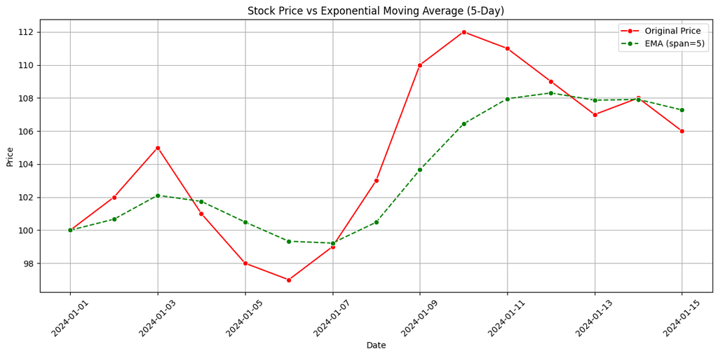

```python
plt.figure(figsize=(12, 6))
sns.lineplot(data=df, x="Date", y="Price", label="Original Price", marker='o', color='red')
sns.lineplot(data=df, x="Date", y="EMA_5", label="EMA (span=5)", linestyle="--", marker='o', color='green')

plt.title("Stock Price vs Exponential Moving Average (5-Day)")
plt.xlabel("Date")
plt.ylabel("Price")
plt.grid(True)
plt.legend()
plt.xticks(rotation=45)
plt.tight_layout()
plt.show()
```

- EMA real-time signals smooth karta hai
- Iska use finance, health sensors, IoT, ML mein hota hai
- Aap isay anomaly detection, pattern prediction, aur data smoothing mein confidently use kar saktay ho

Compare Moving Average | Exponential Moving Average

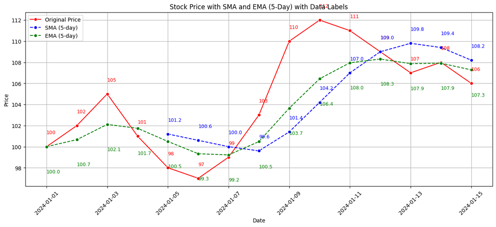

```python
days = pd.date_range(start="2024-01-01", periods=15)
prices = [100, 102, 105, 101, 98, 97, 99, 103, 110, 112, 111, 109, 107, 108, 106]

df = pd.DataFrame({"Date": days, "Price": prices})

df["SMA_5"] = df["Price"].rolling(window=5).mean()
df["EMA_5"] = df["Price"].ewm(span=5, adjust=False).mean()

# Plot
plt.figure(figsize=(13, 6))
sns.lineplot(data=df, x="Date", y="Price", label="Original Price", marker="o", color='red')
sns.lineplot(data=df, x="Date", y="SMA_5", label="SMA (5‑day)", marker="o", linestyle="--", color='blue')
sns.lineplot(data=df, x="Date", y="EMA_5", label="EMA (5‑day)", marker="o", linestyle="--", color='green')

for i in range(len(df)):
    plt.text(df["Date"][i], df["Price"][i] + 1.2, f"{df['Price'][i]}", color='red', fontsize=9)

    if pd.notna(df["SMA_5"][i]):
        plt.text(df["Date"][i], df["SMA_5"][i] + 1.2, f"{df['SMA_5'][i]:.1f}", color='blue', fontsize=9)

    plt.text(df["Date"][i], df["EMA_5"][i] - 2.5, f"{df['EMA_5'][i]:.1f}", color='green', fontsize=9)

plt.title("Stock Price with SMA and EMA (5-Day) with Data Labels")
plt.xlabel("Date")
plt.ylabel("Price")
plt.grid(True)
plt.legend()
plt.xticks(rotation=45)
plt.tight_layout()
plt.show()
```

- SMA(5) ko har naya point ke liye pichlay 5 din ka normal average calculate hota hai — equal weight.
- EMA(5) recent price ko zyada weight deta hai, aur trend changes ko jaldi reflect karta hai.
- Agar koi sharp spike ya dip aata hai, to:
  - SMA isi mutation ko smoother tarah se show karega,
  - EMA us effect ko thoda zyada, lekin soon-after smooth kar lega.

| Feature | SMA (Simple Moving Average) | EMA (Exponential Moving Average) |
| --- | --- | --- |
| **Definition** | Last `k` values ka average | Recent values ko zyada weight deta hai |
| **Weighting** | Har value ka **equal** weight | **Recent values ko zyada** weight milta hai |
| **Responsiveness** | Slow response to recent changes | Fast response to recent changes |
| **Noise Handling** | Better for **removing noise** | Better for **capturing short-term changes** |
| **Lag (Delay)** | Zyada lag (delayed response) | Kam lag (quicker adjustment to trend) |
| **Calculation** | Straightforward rolling average | Recursive formula based on smoothing factor (alpha) |
| **Best For** | Long-term stable trends | Short-term signals / fast-changing trends |
| **Outlier Reaction** | Sudden spike ka asar slow hota hai | Outlier ka effect zyada hota hai initially |
| **Use in Trading** | Long-term support/resistance zones | Entry/Exit signal detection (crossovers etc.) |

| Situation / Use Case | SMA / EMA? | Reason |
| --- | --- | --- |
| 🔍 Long-term trend analysis | ✅ SMA | Stable average, less noise |
| ⚡ Short-term signal detection (e.g. trading) | ✅ EMA | Fast reacts to price changes |
| 📈 Health Monitoring (e.g. heartbeat sensor) | ✅ EMA | Glitches ka asar jaldi samjhta |
| 📉 Noise filtering (smooth curve) | ✅ SMA | Equal weight = less volatility |
| 🧠 ML Feature for trend | ✅ EMA | Adaptive, dynamic |

Summery

| 🔢 Name | 🧮 Formula | 🎯 Core Concept | 🛠️ Core Use Case |
| --- | --- | --- | --- |
| **Mean** (Arithmetic) | `Sum(data) / n` | Sab values ka equal average | General stats, ML feature mean normalization |
| **Median** | `Odd → data[n//2]` `Even → (data[n//2 - 1] + data[n//2]) / 2` | Middle value after sorting | Robust to outliers; income, grades, salaries |
| **Mode** | `Value with highest frequency` | Sab se zyada baar aanay wali value | Categorical data analysis (surveys, NLP, votes) |
| **Geometric Mean** | `(x1 * x2 * ... * xn) ** (1/n)` | Multiplicative mean; lower effect of large values | Growth rate, returns (finance, biology, portfolio growth) |
| **Harmonic Mean** | `n / (1/x1 + 1/x2 + ... + 1/xn)` | Emphasizes small values | Average speed, rates (like km/hr, price per unit) |
| **Trimmed Mean** | `sum(sorted[t : n - t]) / (n - 2t)` | Remove extreme values from both ends | Outlier-resistant average (sensors, clean stats) |
| **Weighted Mean** | `(v1*w1 + v2*w2 + ... + vn*wn) / sum(weights)` | Zyada weight walay values ka zyada asar | GPA calculation, weighted scoring systems |
| **Moving Average (SMA)** | `Sum of last k values / k` | Smooth data over time | Time series smoothing, noise reduction, signal processing |
| **Exponential MA (EMA)** | `α * current + (1 - α) * previous_ema` (α = 2/(span + 1)) | Recent values ko zyada importance | Real-time trends, stock trading signals, sensors |